# Circular Tutorial

Kees Mulder

May 25, 2018

## Circular data

First, load the `circular` package:

```r
library(circular)
```

```r
library(ggplot2)
```

### Working with circular data

A simple circular dataset is in the package, which has arrival times in an intensive care unit:

```r
fisherB1
```

```
##   [1] 11.00 17.00 23.15 10.00 12.00  8.45 16.00 10.00 15.30 20.20  4.00
##  [12] 12.00  2.20 12.00  5.30  7.30 12.00 16.00 16.00  1.30 11.05 16.00
##  [23] 19.00 17.45 20.20 21.00 12.00 12.00 18.00 22.00 22.00 22.05 12.45
##  [34] 19.30 18.45 16.15 16.00 20.30 23.40 20.20 18.45 16.30 22.00  8.45
##  [45] 19.15 15.30 12.00 18.15 14.00 13.00 23.00 19.15 22.00 10.15 12.30
##  [56] 18.15 21.05 21.00  0.30  1.45 12.20 14.45 22.30 12.30 13.15 17.30
##  [67] 11.20 17.30 23.00 10.55 13.30 11.00 18.30 11.05  4.00  7.30 20.00
##  [78] 21.30  6.30 17.30 20.45 22.00 20.15 21.00 17.30 19.50  2.00  1.45
##  [89]  3.40  4.15 23.55  3.15 19.00 21.45 21.30  0.45  2.30 15.30 21.00
## [100]  8.45 14.30 17.00  3.30 15.45 17.30 14.00  2.00 11.30 17.30 17.10
## [111] 21.20  3.00 13.30 23.00 20.10 23.15 20.00 16.00 18.30 21.00 21.10
## [122] 17.00 13.25 15.05 14.10 19.15 14.05 22.40  9.30 17.30 12.30 17.30
## [133] 14.30 16.00 14.10 14.00 15.30  4.30 11.50 11.55 15.20 15.40 11.15
## [144]  2.15 11.15 21.30  3.00  0.40 10.00  9.45 23.45 10.00  7.50 13.30
## [155] 12.30 13.45 19.30  0.15  7.45 15.20 18.40 19.50 23.55  1.45 10.50
## [166]  7.50 15.30 18.00 23.05 19.30 19.00 16.10 10.00  2.30 22.00 21.50
## [177] 19.10 11.45 15.45 16.30 18.30 10.05 20.00 13.35 16.45  2.15 20.30
## [188] 14.00 21.15 18.45 14.05 14.15  1.15  1.45 18.00 14.15 15.15 16.15
## [199] 10.20 13.35 17.15 19.50 22.45  7.25 17.00 12.30 23.15 10.30 13.45
## [210]  2.30 12.00 15.45 17.00 17.00  1.30 20.15 12.30 15.40  3.30 18.35
## [221] 13.30 16.40 18.00 20.00 11.15 16.40 13.55 21.00  7.45 22.30 16.40
## [232] 23.10 19.15 11.00  0.15 14.40 15.45 12.45 17.00 18.00 21.45 16.00
## [243] 12.00  2.30 12.55  2.00 10.30 15.50 17.30 20.00  2.00  1.45  1.45
## [254]  2.05
```

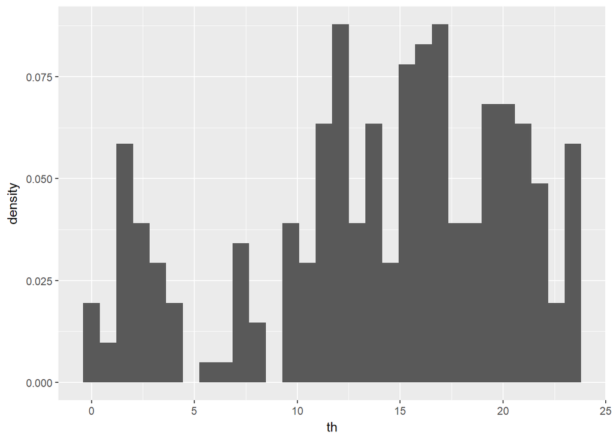

```r
ggplot(data.frame(th = fisherB1)) +
  geom_histogram(aes(x = th, y = ..density..))
```

However, importantly, in order to work with it, we must tell the package that the data is in hours, otherwise all the analyses will be wrong:

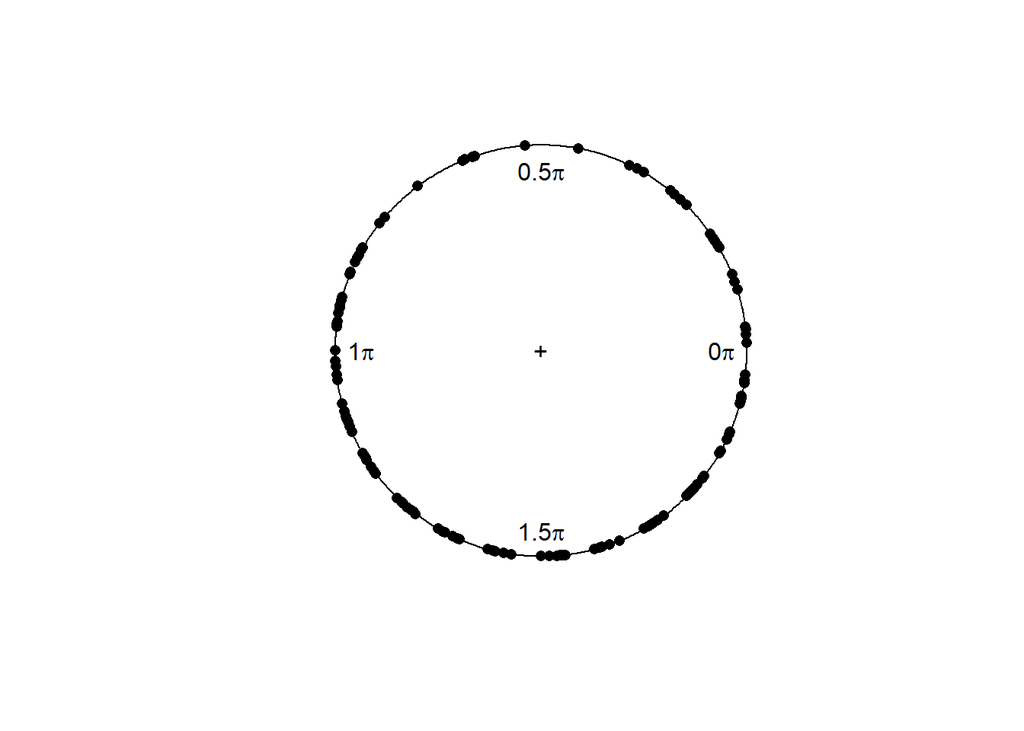

```r
IC_times <- circular(fisherB1, units = "hours")
plot(IC_times)
```

To obtain the mean direction, we use the sum of cosines ($C = \sum_i \text{cos} (\theta_i)$), sum of sines ($S = \sum_i \text{sin} (\theta_i)$) and $R = \sqrt{C^2 + S^2}$, which is the square root of the sum of squared $C$ and $S$ values. The mean direction is then given by

$$\begin{align}
\overline{\theta} &=
\begin{cases}
tan^{-1} (S/C) & S > 0, C > 0\\
tan^{-1} (S/C) + \pi & C < 0\\
tan^{-1} (S/C) + 2\pi & S < 0, C > 0\\
\end{cases}
\text{, (Fisher, 1995)}
\end{align}$$

In `R`, we can get it, but we have to take the modulus of 24 hours to make this interpretable:

```r
mean(IC_times)
```

```
## Circular Data:
## Type = angles
## Units = hours
## Template = none
## Modulo = asis
## Zero = 0
## Rotation = counter
## [1] -6.861651
```

```r
mean(IC_times) %% 24
```

```
## Circular Data:
## Type = angles
## Units = hours
## Template = none
## Modulo = asis
## Zero = 0
## Rotation = counter
## [1] 17.13835
```

### Using circular predictors

Sometimes, we just want to predict a linear outcome $x$ with a circular predictor $\theta$. For example, look at this dataset:

```r
fisherB18
```

```
##    theta     x
## 1    327  28.0
## 2     91  85.2
## 3     88  80.5
## 4    305   4.7
## 5    344  45.9
## 6    270  12.7
## 7     67  72.5
## 8     21  56.6
## 9    281  31.5
## 10     8 112.0
## 11   204  20.0
## 12    86  72.5
## 13   333  16.0
## 14    18  45.9
## 15    57  32.6
## 16     6  56.6
## 17    11  52.6
## 18    27  91.8
## 19    84  55.2
```

Then, we can just do:

```r
fisherB18$theta <- fisherB18$theta * pi / 180
lmfit <- lm(x ~ cos(theta) + sin(theta), data = fisherB18)
lmfit
```

```
##
## Call:
## lm(formula = x ~ cos(theta) + sin(theta), data = fisherB18)
##
## Coefficients:
## (Intercept)   cos(theta)   sin(theta)
##       41.24        11.32        29.27
```

### Fitting a distribution

We can fit a simple distribution on this data:

```r
vm_mles <- mle.vonmises(IC_times)
vm_mles
```

```
##
## Call:
## mle.vonmises(x = IC_times)
##
## mu: -6.862  ( 0.1366 )
##
## kappa: 0.667  ( 0.09615 )
```

And we can see that the fit is fairly well:

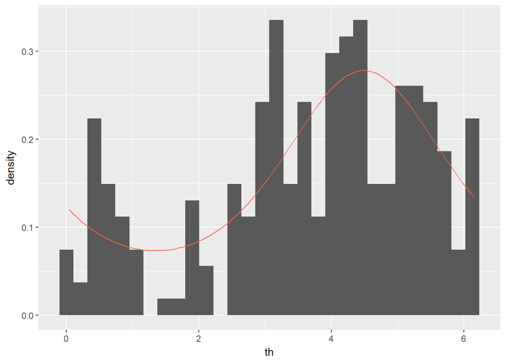

```r
ggplot(data.frame(th = IC_times * pi / 12)) +
  geom_histogram(aes(x = th, y = ..density..)) +
  stat_function(fun = dvonmises,
                args = list(mu = vm_mles$mu, kappa = vm_mles$kappa),
                col = "tomato")
```

### Circular outcome regression

Let’s assume we want to get the circular value predicted by a linear one.

```r
fisherB18
```

```
##        theta     x
## 1  5.7072267  28.0
## 2  1.5882496  85.2
## 3  1.5358897  80.5
## 4  5.3232542   4.7
## 5  6.0039326  45.9
## 6  4.7123890  12.7
## 7  1.1693706  72.5
## 8  0.3665191  56.6
## 9  4.9043752  31.5
## 10 0.1396263 112.0
## 11 3.5604717  20.0
## 12 1.5009832  72.5
## 13 5.8119464  16.0
## 14 0.3141593  45.9
## 15 0.9948377  32.6
## 16 0.1047198  56.6
## 17 0.1919862  52.6
## 18 0.4712389  91.8
## 19 1.4660766  55.2
```

Then, we can just do:

```r
lmc <- lm.circular(fisherB18$x, fisherB18$theta, init = 0, type = "c-l")
lmc
```

```
##
## Call:
## lm.circular.cl(y = ..1, x = ..2, init = 0)
##
##
##  Circular-Linear Regression
##
##  Coefficients:
##      Estimate Std. Error t value Pr(>|t|)
## [1,]   -1.177      2.093   0.563    0.287
##
##  Log-Likelihood:  0.395
##
##  Summary: (mu in radians)
##   mu:  -0.3499 ( 1.153 )  kappa:  0.2906 ( 0.3296 )
## p-values are approximated using normal distribution
```